# SLutils demonstration

Stéphane Laurent

2019-09-10

# 1 Utilities for numbers in character strings

## 1.1 Extraction of numbers from character strings

- The `numextract` function extracts the first number occuring in a character string:

```r
numextract("I am born in 1975 and I am 41 years old.")
## [1] "1975"
```

It can be applied to a vector:

```r
numextract(c("3.5 ml", "7 ml"))
## [1] "3.5" "7"
```

It can be applied to a factor as well:

```r
numextract(factor(c("Batch 101", "Batch 217")))
## [1] "101" "217"
```

- The `numsextract` function extracts all numbers in a character string:

```r
numsextract("I am born in 1975 and I am 41 years old.")
## [1] "1975" "41"
```

## 1.2 Convert from character to numeric

- The `Numerize` function converts a character string to numeric mode if possible:

```r
Numerize(" -3.5")
## [1] -3.5
Numerize("Batch 101")
## Error in Numerize("Batch 101"): not a numerizable character string
```

It can be applied to a vector:

```r
Numerize(c("-3.5", "42"))
## [1] -3.5 42.0
Numerize(c("-3.5", "fourty-two"))
## Error in Numerize(c("-3.5", "fourty-two")): not a numerizable vector
```

And it can be applied to a factor as well:

```r
Numerize(factor(c("00", "01")))
## [1] 0 1
```

## 1.3 Numerize a dataframe

We will use the following dataframe to illustrate the `Numerize.df` function:

```r
dat <- data.frame(u = 1:4,
                  v = c(2.5, -4, 0, 10),
                  w = c("a","b","c","d"),
                  x = factor(c("100", "100", "101", "110")),
                  y = factor(c("Test A", "Test A", "Test B", "Test C")),
                  z = c("1", "1.4", "-3", "   0"),
                  stringsAsFactors = FALSE)
str(dat)
## 'data.frame':    4 obs. of  6 variables:
##  $ u: int  1 2 3 4
##  $ v: num  2.5 -4 0 10
##  $ w: chr  "a" "b" "c" "d"
##  $ x: Factor w/ 3 levels "100","101","110": 1 1 2 3
##  $ y: Factor w/ 3 levels "Test A","Test B",..: 1 1 2 3
##  $ z: chr  "1" "1.4" "-3" "   0"
```

- The `Numerize.df` function numerizes the columns of a dataframe when possible:

```r
Numerize.df(dat) %>% str
## Warning: Columns `w` and `y` are not numerizable.
## 'data.frame':    4 obs. of  6 variables:
##  $ u: int  1 2 3 4
##  $ v: num  2.5 -4 0 10
##  $ w: chr  "a" "b" "c" "d"
##  $ x: num  100 100 101 110
##  $ y: Factor w/ 3 levels "Test A","Test B",..: 1 1 2 3
##  $ z: num  1 1.4 -3 0
##  - attr(*, "unnumerizable")= chr  "w" "y"
```

- You can exclude the factors:

```r
Numerize.df(dat, factors=FALSE) %>% str
## Warning: Column `w` is not numerizable.
## 'data.frame':    4 obs. of  6 variables:
##  $ u: int  1 2 3 4
##  $ v: num  2.5 -4 0 10
##  $ w: chr  "a" "b" "c" "d"
##  $ x: Factor w/ 3 levels "100","101","110": 1 1 2 3
##  $ y: Factor w/ 3 levels "Test A","Test B",..: 1 1 2 3
##  $ z: num  1 1.4 -3 0
##  - attr(*, "unnumerizable")= chr "w"
```

- You can select the columns you want to numerize:

```r
Numerize.df(dat, colnames=c("x", "z")) %>% str
## 'data.frame':    4 obs. of  6 variables:
##  $ u: int  1 2 3 4
##  $ v: num  2.5 -4 0 10
##  $ w: chr  "a" "b" "c" "d"
##  $ x: num  100 100 101 110
##  $ y: Factor w/ 3 levels "Test A","Test B",..: 1 1 2 3
##  $ z: num  1 1.4 -3 0
```

## 1.4 Checking numerizability

- The `isNumerizable` function checks whether a vector or a factor is numerizable:

```r
isNumerizable(c("1.5", "  3.2 "))
## [1] TRUE
isNumerizable(factor(c("3.5", "4")))
## [1] TRUE
isNumerizable(c("100", "AAA"))
## [1] FALSE
## attr(,"unnumerizable")
## AAA
##   2
```

If the result is `TRUE`, the `Numerize` function can be successfully applied (*note:* do not apply `as.numeric` to a factor!).

- The `isNumerizable.df` function checks whether the columns of a dataframe are numerizable:

```r
dat <- data.frame(x = 1:4,
                  y = c("a", "b", "c", "d"),
                  z = c("1", "1.4", "-3", "   0"))
isNumerizable.df(dat)
##     x     y     z
##  TRUE FALSE  TRUE
```

- This function is used by the `coltypes` function:

```r
coltypes(dat)
##   column   class numerizable
## x      x integer        TRUE
## y      y  factor       FALSE
## z      z  factor        TRUE
```

# 2 Numbers utilities

- The `ndecimals` function returns the number of decimal digits of a number:

```r
ndecimals(13.451)
## [1] 3
ndecimals(2)
## [1] 0
ndecimals(pi)
## [1] 15
ndecimals(1.23e-20)
## [1] 22
```

- The `nfloordigits` function returns the number of digits of the integer part of a number:

```r
nfloordigits(13.451)
## [1] 2
nfloordigits(2)
## [1] 1
nfloordigits(-43.4)
## [1] 2
nfloordigits(23.15e6)
## [1] 8
```

- The `prettyNumber` formats a number to a specified number of total characters:

```r
prettyNumber(pi, digits=4)
## [1] "3.14"
prettyNumber(123456789, digits=7)
## [1] "1.2e+08"
prettyNumber(12.5e9, digits=7)
## [1] "1.2e+10"
prettyNumber(0.00000012, digits=7)
## [1] "1.2e-07"
```

- The `number2words` function convert numbers to their corresponding English words:

```r
numbers2words(c(2, 34, 175))
## [1] "two"                          "thirty four"
## [3] "one hundred and seventy five"
```

# 3 Reporting utilities

- The `formatClatex` function formats a number for LaTeX, handling the scientific notation:

```r
formatClatex(1.234567, digits=4)
## [1] "1.235"
formatClatex(1.234567e-12, digits=4)
## [1] "1.235\\mathrm{e}{-12}"
```

- The `numbers2words` function convert numbers to their corresponding English words:

```r
numbers2words(c(2, 17, 211))
## [1] "two"                    "seventeen"
## [3] "two hundred and eleven"
```

- The `enumerate` function makes a sentence enumerating the elements of a vector:

```r
enumerate(letters[1:2])
## [1] "a and b"
enumerate(letters[1:4])
## [1] "a, b, c and d"
```

# 4 Files utilities

- The `findFiles` function finds files before/after a given data with size lower/bigger than a given size. See `?findFiles`.

# 5 Dates utilities

- The `is_date` function checks whether a vector has a date-like class.

```r
x <- Sys.Date()
is_date(x)
## [1] TRUE
is_date(factor(x))
## [1] FALSE
x <- strftime(c("2016-06-21", "2016-11-22"), usetz=TRUE, tz="UTC")
is_date(x)
## [1] FALSE
is_date(as.POSIXct(x, tz="UTC"))
## [1] TRUE
```

- The `possibly_date` function checks whether a vector or a factor can be converted to an object having a date-like class.

```r
x <- Sys.Date()
possibly_date(x)
## [1] TRUE
x <- strftime(c("2016-06-21", "2016-11-22"), usetz=TRUE, tz="UTC")
possibly_date(x)
## [1] TRUE
possibly_date(factor(x))
## [1] TRUE
possibly_date(as.POSIXct(x, tz="UTC"))
## [1] TRUE
x <- Sys.time()
possibly_date(x)
## [1] TRUE
x <- "2016/11/11"
possibly_date(x)
## [1] TRUE
x <- "a"
possibly_date(x)
## [1] FALSE
x <- "11nov1980"
possibly_date(x)
## [1] FALSE
```

Note that `possibly_date("11nov1980")` is `FALSE`. However, `"11nov1980"` can be converted to a date if one specifies the appropriate format, if the locale time is appropriate too:

```r
as.Date("11nov1980", "%d%b%Y") # gives NA in some locales
## [1] NA
Sys.setlocale("LC_TIME", "C")
## [1] "C"
as.Date("11nov1980", "%d%b%Y")
## [1] "1980-11-11"
```

- The `guessDataFormat` guesses the date format of a vector:

```r
guessDateFormat(c("2016/06/21", "2016/11/22"))
## [1] "%Y/%m/%d"
guessDateFormat("11nov1980")
## [1] "%mn%dn%y"
```

It returns `FALSE` if it fails to guess a date:

```r
guessDateFormat("abc")
## [1] FALSE
```

You can also require the dates instead of the format:

```r
guessDateFormat(c("2016/06/21", "2016/11/22"), returnDates=TRUE)
## [1] "2016-06-21 CEST" "2016-11-22 CET"
```

# 6 XLSX utilities

## 6.1 Deprecated functions

- Write the `iris` and `mtcars` dataframes in a XLSX file:

```r
XLSXwrite0(iris, mtcars, file="test.xlsx",
          author="John Doe", title="MyTitle")
```

- See also `?XLSXwrite` to write a worksheet (deprecate in favor of `writeXLSX`), and `?XLSXread`, `?XLSXcomments`, `?XLSXsheets`, `?XLSXtypes` to read from worksheets (deprecated in favor of `hreadXLSX` and `treadXLSX`).

## 6.2 Write a XLSX file from a flat list, allowing different types within columns, based on `openxlsx`

This is achieved by the function `writeXLSX`.

*This function is useful only if you want to write a table which has some columns containing cells of different types.* Otherwise, you can simply use `openxlsx::writeXLSX`.

To do so, the data must be given as a “flat list” (*I don’t know a better name for that*).

This is particularly useful when the original data are given as a JSON string. This is a “flat list”:

```r
( flatlist <- jsonlite::fromJSON("{\"COL1\":[1,null,2],\"COL2\":[\"c\",4],\"Date\":[\"2017-02-12\"]}", simplifyVector=FALSE) )
## $COL1
## $COL1[[1]]
## [1] 1
##
## $COL1[[2]]
## NULL
##
## $COL1[[3]]
## [1] 2
##
##
## $COL2
## $COL2[[1]]
## [1] "c"
##
## $COL2[[2]]
## [1] 4
##
##
## $Date
## $Date[[1]]
## [1] "2017-02-12"
```

The function `writeXLSX` also allows to include some comments in the worksheet.

```r
comments <- jsonlite::fromJSON("{\"COL1\":[\"hello\",null,null],\"COL2\":[null,\"bye\"],\"Date\":[null]}", simplifyVector=FALSE)
```

Now write:

```r
xlsx <- tempfile(fileext=".xlsx")
writeXLSX(flatlist, file=xlsx, comments=comments, sheetname="Sheet1")
## Note: zip::zip() is deprecated, please use zip::zipr() instead
```

We will see below that the worksheet has been written as expected.

## 6.3 XLSX file to flat list or JSON string, based on `tidyxl`

Consider the file created above, whose path is stored in the variable `xlsx`.

```r
sheet <- getExcelSheet(xlsx, sheet="Sheet1")
sheetToJSON(sheet)
## $data
## {"COL1":[1,null,2],"COL2":["c",4,null],"Date":["2017-02-12",null,null]}
##
## $comments
## {"COL1":["hello",null,null],"COL2":[null,"bye",null],"Date":[null,null,null]}
##
## $types
## {"COL1":["numeric",null,"numeric"],"COL2":["character","numeric",null],"Date":["date",null,null]}
```

To get the flat list:

```r
treadXLSX(sheet)
## $data
## $data$COL1
## $data$COL1[[1]]
## [1] 1
##
## $data$COL1[[2]]
## [1] NA
##
## $data$COL1[[3]]
## [1] 2
##
##
## $data$COL2
## $data$COL2[[1]]
## [1] "c"
##
## $data$COL2[[2]]
## [1] 4
##
## $data$COL2[[3]]
## [1] NA
##
##
## $data$Date
## $data$Date[[1]]
## [1] "2017-02-12"
##
## $data$Date[[2]]
## [1] NA
##
## $data$Date[[3]]
## [1] NA
##
##
##
## $comments
## # A tibble: 3 x 3
##   COL1  COL2  Date
##   <chr> <chr> <chr>
## 1 hello <NA>  <NA>
## 2 <NA>  bye   <NA>
## 3 <NA>  <NA>  <NA>
##
## $types
## # A tibble: 3 x 3
##   COL1    COL2      Date
##   <chr>   <chr>     <chr>
## 1 numeric character date
## 2 <NA>    numeric   <NA>
## 3 numeric <NA>      <NA>
```

## 6.4 XLSX file to flat list or JSON string, based on the Haskell library `xlsx`

```r
hreadXLSX(xlsx, sheet="Sheet1", what="data", output="flatlist")
## $COL1
## $COL1[[1]]
## [1] 1
##
## $COL1[[2]]
## NULL
##
## $COL1[[3]]
## [1] 2
##
##
## $COL2
## $COL2[[1]]
## [1] "c"
##
## $COL2[[2]]
## [1] 4
##
## $COL2[[3]]
## NULL
##
##
## $Date
## $Date[[1]]
## [1] "2017-02-12"
##
## $Date[[2]]
## NULL
##
## $Date[[3]]
## NULL

hreadXLSX(xlsx, sheet="Sheet1", what="data", output="dataframe")
##   COL1 COL2       Date
## 1    1    c 2017-02-12
## 2   NA    4       <NA>
## 3    2 <NA>       <NA>

hreadXLSX(xlsx, sheet="Sheet1", what="data", output="JSON")
## [1] "{\"COL1\":[1,null,2],\"COL2\":[\"c\",4,null],\"Date\":[\"2017-02-12\",null,null]}"
```

To read the cell values and the comments, use the option `what="data,comments"` (see `?hreadXLSX` for more info):

```r
hreadXLSX(xlsx, sheet="Sheet1", what="data,comments", output="flatlist")
## $comments
## $comments$COL1
## $comments$COL1[[1]]
## [1] "hello"
##
## $comments$COL1[[2]]
## NULL
##
## $comments$COL1[[3]]
## NULL
##
##
## $comments$COL2
## $comments$COL2[[1]]
## NULL
##
## $comments$COL2[[2]]
## [1] "bye"
##
## $comments$COL2[[3]]
## NULL
##
##
## $comments$Date
## $comments$Date[[1]]
## NULL
##
## $comments$Date[[2]]
## NULL
##
## $comments$Date[[3]]
## NULL
##
##
##
## $data
## $data$COL1
## $data$COL1[[1]]
## [1] 1
##
## $data$COL1[[2]]
## NULL
##
## $data$COL1[[3]]
## [1] 2
##
##
## $data$COL2
## $data$COL2[[1]]
## [1] "c"
##
## $data$COL2[[2]]
## [1] 4
##
## $data$COL2[[3]]
## NULL
##
##
## $data$Date
## $data$Date[[1]]
## [1] "2017-02-12"
##
## $data$Date[[2]]
## NULL
##
## $data$Date[[3]]
## NULL

hreadXLSX(xlsx, sheet="Sheet1", what="data,comments", output="JSON")
## [1] "{\"comments\":{\"COL1\":[\"hello\",null,null],\"COL2\":[null,\"bye\",null],\"Date\":[null,null,null]},\"data\":{\"COL1\":[1,null,2],\"COL2\":[\"c\",4,null],\"Date\":[\"2017-02-12\",null,null]}}"
```

## 6.5 Benchmarks

- Benchmark for a small worksheet:

```r
library(microbenchmark)
microbenchmark(
  tidyxl = treadXLSX(getExcelSheet(xlsx, sheet="Sheet1")),
  haskell = hreadXLSX(xlsx, sheet="Sheet1", what="data,comments,types", output="flatlist"),
  times=20
)
## Unit: milliseconds
##     expr      min        lq     mean    median       uq       max neval
##   tidyxl  75.6621  84.41313 114.5440  96.05402 112.1522  288.7248    20
##  haskell 463.8033 575.28391 679.5321 647.18107 691.1877 1666.4587    20
##  cld
##   a
##    b
microbenchmark(
  tidyxl = sheetToJSON(getExcelSheet(xlsx, sheet="Sheet1")),
  haskell = hreadXLSX(xlsx, sheet="Sheet1", what="data,comments,types", output="JSON"),
  times=20
)
## Unit: milliseconds
##     expr      min       lq      mean    median        uq      max neval
##   tidyxl 124.5417 155.7418  233.0064  253.4969  298.0697  394.638    20
##  haskell 594.5326 826.9307 1116.6621 1083.8277 1369.2279 1928.185    20
##  cld
##   a
##    b
```

- Benchmark for a bigger worksheet:

```r
xlsx <- system.file("extdata", "datasets.xlsx", package="readxl")
library(microbenchmark)
microbenchmark(
  tidyxl = treadXLSX(getExcelSheet(xlsx, sheet="iris")),
  haskell = hreadXLSX(xlsx, sheet="iris", what="data,comments,types", output="flatlist"),
  times=20
)
## Unit: milliseconds
##     expr       min        lq     mean    median       uq      max neval
##   tidyxl 3171.4613 3417.8009 4892.262 3982.7001 5565.538 9629.088    20
##  haskell  697.1762  714.9895 1000.297  802.6453 1205.371 1968.424    20
##  cld
##    b
##   a
microbenchmark(
  tidyxl = sheetToJSON(getExcelSheet(xlsx, sheet="iris")),
  haskell = hreadXLSX(xlsx, sheet="iris", what="data,comments,types", output="JSON"),
  times=20
)
## Unit: milliseconds
##     expr       min        lq     mean   median       uq      max neval cld
##   tidyxl 3201.9289 3286.4980 4829.708 3399.537 5985.511 9017.678    20   b
##  haskell  700.3579  877.8446 1120.316 1069.440 1211.694 2112.136    20  a
```

# 7 Stats utilities

## 7.1 Type II ANOVA table

- Get type II ANOVA table for a model like `lm(y~a+b+a:b)`:

```r
fit <- lm(yield ~ block + N + block:N, data=npk)
typeIItable(fit)
## Anova Type II Table
##
##           Df Sum Sq Mean Sq F value  Pr(>F)
## block      5 343.29  68.659  3.3592 0.03967 *
## N          1 189.28 189.282  9.2607 0.01021 *
## block:N    5  98.52  19.704  0.9640 0.47690
## Residuals 12 245.27  20.439
## ---
## Signif. codes:  0 '***' 0.001 '**' 0.01 '*' 0.05 '.' 0.1 ' ' 1
```

This function does not require any external package. The output is the same as the one of the `car::Anova` function:

```r
car::Anova(fit)
## Anova Table (Type II tests)
##
## Response: yield
##           Sum Sq Df F value  Pr(>F)
## block     343.30  5  3.3592 0.03967 *
## N         189.28  1  9.2607 0.01021 *
## block:N    98.52  5  0.9640 0.47690
## Residuals 245.27 12
## ---
## Signif. codes:  0 '***' 0.001 '**' 0.01 '*' 0.05 '.' 0.1 ' ' 1
```

## 7.2 Noncentral Student t distribution

According to the R documentation of the Student t distribution (`?TDist`), the functions `pt` and `qt` do not return a correct value when `abs(ncp)>37.62`, where `ncp` is the non-centrality parameter.

The functions `pT` and `qT` in the `SLutils` package achieve a better performance. Actually they are copied from the `EnvStats` package.

```r
ncp <- 40
pt(q=30, df=10, ncp=ncp)
## [1] 0.05648305
pT(q=30, df=10, ncp=ncp)
## [1] 0.06057775
qt(p=0.5, df=10, ncp=ncp)
## [1] 41.02564
qT(p=0.5, df=10, ncp=ncp)
## [1] 41.38075
```

These values returned by `pT` and `qT` coincide with the ones calculated by [the keisan online calculator](http://keisan.casio.com/exec/system/1180573219) as well as the ones calculated by WolframAlpha ([pT value](https://www.wolframalpha.com/input/?i=N%5BCDF%5BNoncentralStudentTDistribution%5B10,40%5D,30%5D%5D) and [qT value](https://www.wolframalpha.com/input/?i=N%5BinverseCDF%5BNoncentralStudentTDistribution%5B10,40%5D,0.5%5D%5D)).

## 7.3 The Dunnett distribution

Let $(X_1, \ldots, X_k)$ be a $k$-dimensional random vector following a centered [multivariate Student distribution](https://en.wikipedia.org/wiki/Multivariate_t-distribution) with $\nu$ degrees of freedom and scale (covariance) matrix
$$\begin{pmatrix}
1 & \rho & \cdots & \rho \\
\rho & \ddots & \ddots & \vdots \\
\vdots & \ddots & \ddots & \rho \\
\rho & \cdots & \rho & 1
\end{pmatrix}.$$
We denote by $S_k(\nu, \rho)$ this distribution.

The cumulative distribution function, the quantile function and the sampling function of these distributions are implemented under the names `pDunnett`, `qDunnett` and `rDunnett`, respectively.

## 7.4 Application: exact prediction intervals

Consider an actual sample $y_1, \ldots, y_n \sim_{\text{iid}} {\cal N}(\mu,\sigma^2)$ and $k$ future observations $y^\ast_{1}, \ldots, y^\ast_k \sim_{\text{iid}} {\cal N}(\mu,\sigma^2)$.

Then it can be shown that
$$\left(\frac{y^\ast_1 - \bar y}{\sqrt{1+\frac{1}{n}}sd(y)},
\ldots,
\frac{y^\ast_k - \bar y}{\sqrt{1+\frac{1}{n}}sd(y)}\right) \sim S_k(n-1, \rho)$$
with $\rho = \dfrac{1}{n+1}$.

Therefore, setting $t_i = \frac{y^\ast_i - \bar y}{\sqrt{1+\frac{1}{n}}sd(y)}$,  
if $q_1$ and $q_2$ are the $100(1-\alpha)\%$-quantiles of $D_1(k, n-1, \rho)$ and $D_2(k, n-1, \rho)$ respectively, then we are $100(1-\alpha)\%$-confident that, *simultaneously* for all $i \in \{1, \ldots, k\}$, the inequalities $t_i \leqslant q_1$ and $|t_i| \leqslant q_2$ hold true.

The first inequality yields an upper $100(1-\alpha)\%$-prediction interval for the $k$ future observations, while the second one yields a two-sided $100(1-\alpha)\%$-prediction interval.

More precisely, the upper prediction bound given by the first inequality is
$$\bar y + q_1\sqrt{1+\frac{1}{n}}sd(y)$$
and the two prediction bounds given by the second inequality are
$$\bar y \pm q_2\sqrt{1+\frac{1}{n}}sd(y).$$

The factors $q_1\sqrt{1+\frac{1}{n}}$ and $q_2\sqrt{1+\frac{1}{n}}$ are returned by the function `predictionFactor` with option `method="exact"`, and the prediction intervals are returned by the function `predictionInterval` with option `method="exact"`.

There is also the function `CoverageEPI`, which estimates the coverage probability of these prediction intervals with the help of simulations.

# 8 Breakpoints

## 8.1 The example dataset

```r
data(dataBP)
head(dataBP)
##         date          y
## 1 2012-01-25   1.673111
## 2 2012-02-07  -5.403228
## 3 2012-02-10  -1.395732
## 4 2012-02-10 -19.564536
## 5 2012-02-14  11.973142
## 6 2012-02-17  32.180667
```

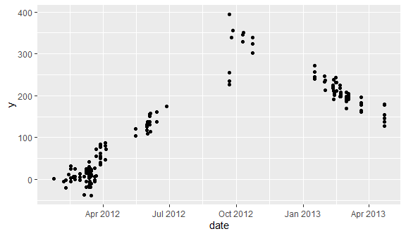

```r
gg <- ggplot(dataBP, aes(x=date, y=y)) + geom_point()
gg
```

## 8.2 Constant piecewise model

### 8.2.1 Find a single breakpoint - constant piecewise

```r
# find breakpoint
bp <- breakpoints(y~1, dat=dataBP, onebreak=TRUE)
# number of breakpoints (here, 0 or 1)
( n.bp <- length(bp$breakpoint) )
## [1] 1
paste("Breakpoint:", dataBP$date[bp$breakpoint])
## [1] "Breakpoint: 2012-05-16"
```

Show the result on a graphic:

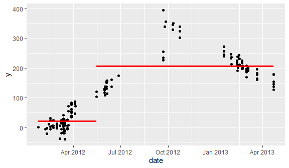

```r
breakdates <- c(dataBP$date[1], dataBP$date[bp$breakpoint], tail(dataBP$date,1))
x <- breakdates[1:2]
xend <- breakdates[2:3]
y <- yend <- bp$coef[1:2]
segs <- data.frame(x,xend,y,yend)
gg +
  geom_segment(data=data.frame(mygroup=c(NA,NA)),
               aes(x=segs[,1], y=segs[,3], xend=segs[,2], yend=segs[,4]),
               colour="red", linetype="solid", size=1.2)
```

### 8.2.2 Find several breakpoints - constant piecewise

When looking for several breakpoints:

- set the option `onebreak=FALSE`
- set the maximal number of breakpoints with the option `nbreaks.max`
- or set `nbreaks.max=NULL` to find the optimal number of breakpoints

```r
# find breakpoints
bp <- breakpoints(y~1, dat=dataBP, onebreak=FALSE, nbreaks.max=NULL)
# number of breakpoints
( n.bp <- length(bp$breakpoint) )
## [1] 3
paste("Breakpoints:", paste(dataBP$date[bp$breakpoint], collapse=", "))
## [1] "Breakpoints: 2012-03-23, 2012-06-27, 2013-02-11"
```

Show the result on a graphic:

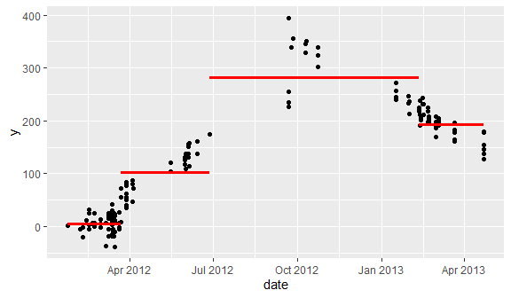

```r
breakdates <- c(dataBP$date[1], dataBP$date[bp$breakpoint], tail(dataBP$date,1))
x <- breakdates[1:(n.bp+1)]
xend <- breakdates[1+1:(n.bp+1)]
y <- yend <- bp$coef[1:(n.bp+1)]
segs <- data.frame(x,xend,y,yend)
gg +
  geom_segment(data=data.frame(mygroup=rep(NA, n.bp+1)),
               aes(x=segs[,1], y=segs[,3], xend=segs[,2], yend=segs[,4]),
               colour="red", linetype="solid", size=1.2)
```

## 8.3 Linear piecewise model

### 8.3.1 Find a single breakpoint - linear piecewise

```r
dataBP <- transform(dataBP, dateID=as.integer(date))
# find breakpoint
bp <- breakpoints(y~dateID, dat=dataBP, onebreak=TRUE)
# number of breakpoints (here, 0 or 1)
( n.bp <- length(bp$breakpoint) )
## [1] 1
paste("Breakpoint:", dataBP$date[bp$breakpoint])
## [1] "Breakpoint: 2012-09-21"
```

Show the result on a graphic:

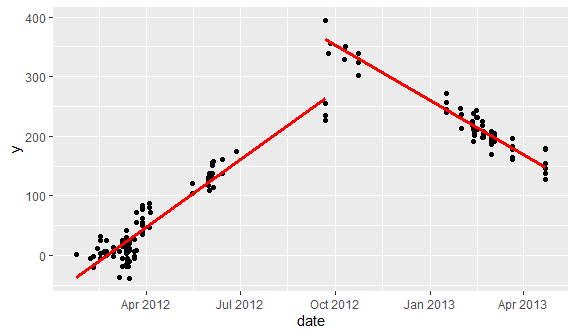

```r
breakdates <- c(dataBP$date[1], dataBP$date[bp$breakpoint], tail(dataBP$date,1))
nbreakdates <- c(dataBP$dateID[1], dataBP$dateID[bp$breakpoint], tail(dataBP$dateID,1))
a <- bp$coef[,1]
b <- bp$coef[,2]
x <- breakdates[1:2]
xend <- breakdates[2:3]
y <- a+b*nbreakdates[1:2]
yend <- a+b*nbreakdates[2:3]
segs <- data.frame(x,xend,y,yend)
gg +
  geom_segment(data=data.frame(mygroup=rep(NA,2)),
               aes(x=segs[,1], y=segs[,3], xend=segs[,2], yend=segs[,4]),
               colour="red", linetype="solid", size=1.2)
```

### 8.3.2 Find several breakpoints - linear piecewise

```r
# find breakpoints
bp <- breakpoints(y~dateID, dat=dataBP, onebreak=FALSE, nbreaks.max=NULL)
# number of breakpoints
( n.bp <- length(bp$breakpoint) )
## [1] 2
paste("Breakpoints:", paste(dataBP$date[bp$breakpoint], collapse=", "))
## [1] "Breakpoints: 2012-03-23, 2012-09-21"
```

Show the result on a graphic:

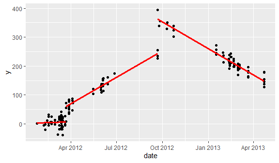

```r
breakdates <- c(dataBP$date[1], dataBP$date[bp$breakpoint], tail(dataBP$date,1))
nbreakdates <- c(dataBP$dateID[1], dataBP$dateID[bp$breakpoint],  tail(dataBP$dateID,1))
a <- bp$coef[,1]
b <- bp$coef[,2]
x <- breakdates[1:(n.bp+1)]
xend <- breakdates[1+1:(n.bp+1)]
y <- a+b*nbreakdates[1:(n.bp+1)]
yend <- a+b*nbreakdates[1+1:(n.bp+1)]
segs <- data.frame(x,xend,y,yend)
gg +
  geom_segment(data=data.frame(mygroup=rep(NA,n.bp+1)),
               aes(x=segs[,1], y=segs[,3], xend=segs[,2], yend=segs[,4]),
               colour="red", linetype="solid", size=1.2)
```

# 9 CRAN-like repo utilities

- Initialize a repo with `makeRepo`:

```r
makeRepo("U:/CRANrepo", name="myCRANrepo")
```

This creates the following structure:

```
U:\CRANREPO
│   myCRANrepo.name
│
├───bin
│   ├───macosx
│   │   ├───contrib
│   │   │   └───3.3
│   │   ├───leopard
│   │   │   └───contrib
│   │   │       └───3.3
│   │   └───mavericks
│   │       └───contrib
│   │           └───3.3
│   └───windows
│       └───contrib
│           └───3.3
│               ├───Archive
│               └───Meta
└───src
    └───contrib
        ├───Archive
        └───Meta
```

- Add one package in the repo:

```r
addPackage("U:/CRANrepo", "mypackage.tar.gz")
```

If there are several versions of this package in the repo, the older ones will be archived.

- You can also add some packages (tarballs) by hand in the `src/contrib` folder, and then use `writePACKAGESandArchive` to update the repo.

# 10 Strings utilities

- The `string2letters` function separates the characters of a string:

```r
string2letters("hello")
## [1] "h" "e" "l" "l" "o"
```

- The `charseq` function generates consecutive integers with a given number of digits:

```r
charseq(12)
##  [1] "01" "02" "03" "04" "05" "06" "07" "08" "09" "10" "11" "12"
## attr(,"string")
## character(0)
```

- It can be used with a prefix and a suffix:

```r
charseq(12, prefix="graph", suffix=".png")
##  [1] "graph01.png" "graph02.png" "graph03.png" "graph04.png" "graph05.png"
##  [6] "graph06.png" "graph07.png" "graph08.png" "graph09.png" "graph10.png"
## [11] "graph11.png" "graph12.png"
## attr(,"string")
## [1] "graph%02d.png"
```

# 11 Matrices utilities

- Generates blocks diagonal matrices:

```r
M1 <- diag(2); M2 <- matrix(2, nrow=3, ncol=3)
blockdiag(M1,M2)
##      [,1] [,2] [,3] [,4] [,5]
## [1,]    1    0    0    0    0
## [2,]    0    1    0    0    0
## [3,]    0    0    2    2    2
## [4,]    0    0    2    2    2
## [5,]    0    0    2    2    2
blockdiag_list(list(M1,M2,M1))
##      [,1] [,2] [,3] [,4] [,5] [,6] [,7]
## [1,]    1    0    0    0    0    0    0
## [2,]    0    1    0    0    0    0    0
## [3,]    0    0    2    2    2    0    0
## [4,]    0    0    2    2    2    0    0
## [5,]    0    0    2    2    2    0    0
## [6,]    0    0    0    0    0    1    0
## [7,]    0    0    0    0    0    0    1
```

# 12 The `Sys.which2` function

This function is like `Sys.which` but it finds an executable without including the Windows system directories before `PATH`.

It is useful for example on Windows when you want to find the executable `convert` of ImageMagick, because `Sys.which` first looks in the Windows system directories and finds another executable:

```r
Sys.which("convert")
##                              convert
## "C:\\Windows\\system32\\convert.exe"
```

# 13 Conversion of pdf/ps figures to png/gif

- The `pspdfimg` function converts a ps or pdf figure to a png or gif figure. It requires ImageMagick and Ghostscript. This is the example given in `?pspdfimg`:

```r
# generates a pdf figure
pdf("imgs/Rplot01.pdf", width=5, height=5)
curve(x^2, from=-1, to=1, axes=FALSE, ylab=NA, col="red")
xlabs_at <- seq(-1, 1, by=0.5)
axis(1, at=xlabs_at)
ylabs_at <- seq(0, 1, by=0.2)
axis(2, at=ylabs_at)
text(0.65, 0.8, expression(f(x)==x^2))
dev.off()
## png
##   2
# converts to png
pspdf2img("imgs/Rplot01.pdf", format="png", moreopts="-trim -resize 30%")
```

It generates this png image:

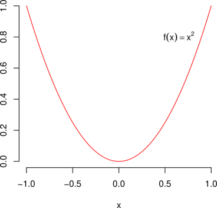

Of course this example is an artifical one: there’s no need to firstly generate a pdf figure to get this png figure. But go to the next section now.

# 14 Conversion of R plots to TikZ figures

## 14.1 A basic plot example

```r
# first write a function creating the plot
plotCode <- function(){
  curve(x^2, from=-1, to=1, axes=FALSE, xlab="$x$", ylab=NA, col="red")
  xlabs_at <- seq(-1, 1, by=0.5)
  axis(1, at=xlabs_at, labels=dollarify()(xlabs_at))
  ylabs_at <- seq(0, 1, by=0.2)
  axis(2, at=ylabs_at, labels=dollarify()(ylabs_at))
  text(0.65, 0.8, "$f(x)=x\\\\^2$") # note the four backslashes!
  return(invisible())
}
# create the LaTeX file with default preamble for pdflatex
plot2tikz(plotCode, filename="Rplot02", outdir="./imgs",
          compile=TRUE, clean=TRUE,
          documentDeclaration ="\\documentclass[12pt]{standalone}\n",
          width=5, height=5)
```

Now you get a TikZ figure in the file `Rplot02.pdf`. You can convert it to png as before:

```r
pspdf2img("imgs/Rplot02.pdf", format="png", moreopts="-trim -resize 30%")
```

And you get this png image:

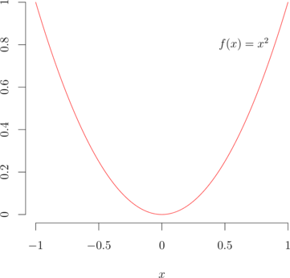

Note that we used the `dollarify` function in the code above, to surround the axes labels between `$`’s. This function is provided by `SLutils`. It is more useful for `ggplot2` graphics.

## 14.2 A `ggplot2` example

Now let’s create a TikZ figure from a `ggplot2` plot. We use the `datify` function to get beautiful dates (see `?datify`).

- First we create the `ggplot2` plot, with LaTeX axes labels and titles:

```r
library(ggplot2)
set.seed(666)
DF <- data.frame(date = rep(Sys.Date()+1:10, 2),
                 y = rpois(20, 50),
                 group = gl(2, 10, labels=c("A","B")))
base_size <- 20
gg <- ggplot(DF, aes(x=date, y=y)) +
  geom_point(size=3, color="white", shape=21, fill="green") +
  scale_y_continuous(labels=dollarify()) +
  scale_x_date(date_breaks="2 days", labels=datify()) +
  # the labeller below is a trick to control the width of the strips
  # see http://stackoverflow.com/questions/17825201/is-there-a-way-to-increase-the-height-of-the-strip-text-bar-in-a-facet
  facet_grid(group ~ ., labeller=labeller(group=setNames(paste0("\ngroup ", levels(DF$group), "\n"), levels(DF$group)))) +
  xlab("\\large\\textsf{date}") +
  ylab("\\Large $y$") +
  theme(panel.background = element_rect(fill="black", color=NA),
        panel.grid.major = element_line(color="blue4", size=1, linetype="dashed"),
        panel.grid.minor = element_line(color="blue", size=0.5, linetype="dashed"),
        panel.border = element_rect(fill=NA, color="red"),
        panel.spacing = unit(1, "lines"),
        strip.background = element_rect(fill="grey30", color="grey10"),
        strip.text = element_text(color="white", size=base_size, lineheight=0.5),
        plot.background = element_rect(color="black", fill="black"),
        plot.title = element_text(size=base_size*1.2, color="white"),
        plot.margin = margin(t=1, r=1, b=1, l=1, "lines"),
        axis.line = element_blank(),
        axis.text.x = element_text(face="bold", angle=45, vjust=0.5, size=base_size*0.6, color="white", lineheight=0.9),
        axis.text.y = element_text(face="bold", size=base_size*0.8, color="white", lineheight=0.9, hjust=1),
        axis.ticks = element_line(colour = "white", size=0.2),
        axis.title.x = element_text(size = base_size*0.9, color="white", vjust=0),
        axis.title.y = element_text(face="bold", size=base_size*0.8, color="white", angle=90, vjust=1),
        axis.ticks.length = unit(0.3, "lines"),
        axis.text = element_text(margin=unit(0.5, "lines"))
  )
```

```r
plot2tikz(function() print(gg),
          filename="Rplot03", outdir="./imgs",
          compile=TRUE, clean=TRUE, overwrite = TRUE,
          packages=c("\\usepackage[ddmmyyyy]{datetime}\n"),
          documentDeclaration ="\\documentclass[12pt]{standalone}\n",
          width=7, height=5)
```

Now we get a TikZ figure in the file `Rplot03.pdf`. We convert it to png:

```r
pspdf2img("imgs/Rplot03.pdf", format="png", moreopts="-resize 30%")
```

And we get this png image:

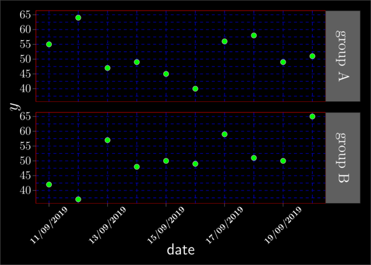

# 15 Scianimator animations

See the example:

```r
browseURL(system.file("scianimator", "example", "scianim_example.html", package="SLutils"))
```

This example was created by the following code:

```r
# taken from ?tikz2png
plotCode <- function(n){
  curve(x^n, from=-1, to=1, axes=FALSE,
        ylab=NA, xlab="$x$",
        main=sprintf("$f(x)=x\\\\^%s$", n))
  xlabs_at <- seq(-1, 1, by=0.5)
  axis(1, at=xlabs_at, labels=dollarify()(xlabs_at))
  ylabs_at <- seq(ifelse(n%%2==0, 0, -1), 1, by=0.2)
  axis(2, at=ylabs_at, labels=dollarify()(ylabs_at))
  return(invisible())
}
# write images
imgs <- tikz2png(plotCode, 1:10, bg="white")
# create scianimation
scianim("scianim_example", imgs=imgs, theme="dark")
# remove files
file.remove(list.files(pattern="^Rplot"))
```

# 16 Shiny apps

## 16.1 Reshape (pivot) a table

- Run `shinyReshape(dat)` to reshape a dataframe `dat`, or run `shinyReshape()` to upload a table and reshape it.